# Small Steps Are Great Progress

## Aaron P Titus, High Point University

# Thinking Iteratively

## Ways to find me

[@aaronptitus](https://twitter.com/aaronptitus)

atitus@highpoint.edu

https://github.com/atitus

## Explore

- GlowScript.org (http://www.glowscript.org/)
- M&I lecture demo programs ([http://matterandinteractions.org/student](http://www.glowscript.org/#/user/GlowScriptDemos/folder/Examples/program/MatterAndInteractions))
- VPython (http://vpython.org/)

# Acknowledgements

- Ruth Chabay and Bruce Sherwood

[figure not shown]

# Methods to Write/Run VPython

1. Classic VPython (www.vpython.org)
2. GlowScript (www.glowscript.org)
3. Jupyter Notebook (formerly iPython Notebook)
   1. Install Anaconda (https://www.continuum.io/downloads)
   2. Install iVisual (https://pypi.python.org/pypi/IVisual/) by John Coady. It enables GlowScript within a Jupyter Notebook.
   3. Embed markup, html, LaTeX
   4. Use Jupyter for tutorials, lab reports, computational projects, data analysis, data visualization, and even presentations!

# Recommendation

- Use GlowScript or Classic VPython for introductory physics students
- Use Jupyter Notebook for intermediate and advanced classes (Modern Physics +...)

# GlowScript VPython

[figure not shown]

A JavaScript library and web-based application based on the visual package available from vpython.org. GlowScript gives you:

- A web-based editor
- Conversion of Python to JavaScript
- 3D graphics
- Automatic scaling (real-world units to pixels)
- Vector operations

```python
from IPython.display import IFrame
IFrame('http://www.glowscript.org/#/user/Aaron_Titus/folder/SETI/program/earth-mars-orbits', width=700, height=500)
```

[interactive chart not shown]

# Growth of GlowScript Users

```python
IFrame('http://www.glowscript.org/#/user/Bruce_Sherwood/folder/My_Programs/program/Users', width=700, height=500)
```

[interactive chart not shown]

# Steps to Teaching Iterative Thinking -- Vectors

Create a VPython program that places spheres at the vertices of a square pyramid and connects the vertices with cylinders.

[figure not shown]

## Import the package

This line (or lines) depends on whether you are using Classic VPython, GlowScript, or Jupyter Notebook.

```python
#Import Packages
#
# This step depends on the platform: GlowScript, Jupyter Notebook, or Classic VPython

from __future__ import division, print_function
from ivisual import *
from math import *
```

```python
#square pyramid

#Create the scene
scene=canvas(title="3D Scene")

#radius of sphere
R=0.05

#radius of cylinder
Rcyl=R/4

#color of sphere
spherecolor=color.yellow

#color of cylinder
cylcolor=color.white

#spheres
s1=sphere(pos=vector(1,0,0), radius=R, color=spherecolor)
s2=sphere(pos=vector(-1,0,0), radius=R, color=spherecolor)
s3=sphere(pos=vector(0,0,1), radius=R, color=spherecolor)
s4=sphere(pos=vector(0,0,-1), radius=R, color=spherecolor)
s5=sphere(pos=vector(0,1,0), radius=R, color=spherecolor)

#cylinders
cylinder(pos=s1.pos, axis=s3.pos-s1.pos, radius=Rcyl, color=cylcolor)
cylinder(pos=s1.pos, axis=s4.pos-s1.pos, radius=Rcyl, color=cylcolor)
cylinder(pos=s1.pos, axis=s5.pos-s1.pos, radius=Rcyl, color=cylcolor)
cylinder(pos=s2.pos, axis=s3.pos-s2.pos, radius=Rcyl, color=cylcolor)
cylinder(pos=s2.pos, axis=s4.pos-s2.pos, radius=Rcyl, color=cylcolor)
cylinder(pos=s2.pos, axis=s5.pos-s2.pos, radius=Rcyl, color=cylcolor)
cylinder(pos=s3.pos, axis=s5.pos-s3.pos, radius=Rcyl, color=cylcolor)
cylinder(pos=s4.pos, axis=s5.pos-s4.pos, radius=Rcyl, color=cylcolor)
```

```
<ivisual.visual.cylinder at 0x106e86210>
```

# Steps to Teaching Iterative Thinking -- Velocity

## Position Update

For a small time interval $\Delta t$,

$$\vec{r}_{future} = \vec{r}_{now} + \vec{v}\Delta t$$

In VPython, if you create an object named **particle** then update its position using:

```
particle.pos = particle.pos + v * dt
```

[figure not shown]

(from *Matter and Interactions*)

[figure not shown]

(from *Matter and Interactions*)

```python
#uniform motion -- a ball on a level track

scene=canvas(title="3D Scene", height=250, width=600)

ball=sphere(pos=vector(-1.5,0,0), radius=0.05, color=color.cyan)
track=box(pos=vector(0,-0.075,0), size=(3,0.05,0.1), color=color.white)

v=vector(0.3,0,0)

dt=0.01
t=0

while ball.pos.x<1.5:
    rate(100)
    ball.pos = ball.pos + v*dt
    t=t+dt
```

# Steps to Teaching Iterative Thinking -- The Momentum Principle

## Momentum Update

For a small time interval $\Delta t$,

$$\vec{p}_{future}=\vec{p}_{now} + \vec{F}_{net,now}\Delta t$$

This is the **update form** of the Momentum Principle.

[figure not shown]

(from *Matter and Interactions*)

The momentum now contains the history of the impulses on the particle, but the future momentum depends on the net force now.

[figure not shown]

(from *Matter and Interactions*)

# Euler-Cromer Method

1. Calculate the net force on the particle.
2. Update the particle's momentum.
3. Update the particle's position.

For non-relativistic motion,

$$\vec{v}\approx \vec{v}_f \approx \frac{\vec{p}}{m}.$$

For an object named **particle**, the vpython code would look like this.

```
Fnet = vector(0,-10*m,0)
    p = p + Fnet * dt
    particle.pos = particle.pos + p/m * dt
```

```python
#constant force

scene=canvas(title="3D Scene", height=500, width=600)


#clickToAdvance does not work in Jupyter at the moment
#print("If clickToAdvance==True, then click on the scene to advance the simulation to the next calculation.")
#print("Change clickToAdvance to False if you want the program to advance automatically.")

#set this to True if you want to click to advance through the calculations and steps
#set this to False if you want it to advance automatically
clickToAdvance=False

t = 0

#use case 1 if clicking to advance
#use any case if not clicking to advance
thiscase=1

if(thiscase==1):
        dt = 0.25
        max=100
        rateTime=100

if(thiscase==2):
        dt = 0.1
        max=50
        rateTime=100

if(thiscase==3):
        dt = 0.01
        max=25
        rateTime=1000


floor = box(pos=vector(0,0,0), size=vector(10.0,0.05,10), color=color.green)
ball = sphere(pos=vector(-4.5,0.1,0), radius=0.4, color=color.white, opacity=0.5)

ball.m = 0.8
ball.v = vector(5.74,8.19,0)
ball.p = ball.m * ball.v
g = 9.8

scenerange=5
scene.range=scenerange
scene.background=color.black

trail=curve(color=ball.color)
trail.append(pos=ball.pos)

zeroVector=vector(0,0,0)

arrowScale=scenerange/mag(ball.v)
vArrow=arrow(pos=ball.pos, axis=vector(0,0,0), color=color.yellow, shaftwidth=0.1)
dvArrow=arrow(pos=vArrow.pos+vArrow.axis, axis=vector(0,0,0), color=color.magenta, shaftwidth=0.1)
vfArrow=arrow(pos=ball.pos, axis=vector(0,0,0), color=color.cyan, shaftwidth=0.1)
drArrow=arrow(pos=ball.pos,axis=vector(0,0,0), color=ball.color, shaftwidth=0.1)

#if(clickToAdvance==False):
#        scene.waitfor('click')

while ball.pos.y>0:
        rate(10)
        if(clickToAdvance==True):
            scene.waitfor('click')
        vArrow.pos=ball.pos
        vArrow.axis=ball.v*arrowScale
        if(clickToAdvance==False):
                for i in range(0,max):
                        rate(rateTime)
        Fnet=vector(0,-ball.m*g,0)
        ball.p = ball.p + Fnet*dt
        ball.v = ball.p/ball.m
        dv = Fnet/ball.m*dt
        dr = ball.v*dt

        if(clickToAdvance==True):
            scene.waitfor('click')
        dvArrow.pos=vArrow.pos+vArrow.axis
        dvArrow.axis=dv*arrowScale
        if(clickToAdvance==False):
                for i in range(0,max):
                        rate(rateTime)

#        if(clickToAdvance==True):
#            scene.waitfor('click')
        vfArrow.pos=ball.pos
        vfArrow.axis=vArrow.axis+dvArrow.axis
        if(clickToAdvance==False):
                for i in range(0,max):
                        rate(rateTime)

#        if(clickToAdvance==True):
#            scene.waitfor('click')

        drArrow.pos=ball.pos
        drArrow.axis=dr

        if(clickToAdvance==False):
                for i in range(0,max):
                        rate(rateTime)
#        if(clickToAdvance==True):
#            scene.waitfor('click')

        vArrow.axis=zeroVector
        dvArrow.axis=zeroVector
        vfArrow.axis=zeroVector
        ball.pos=ball.pos+ball.v*dt
        t = t+dt
        trail.append(pos=ball.pos)

        #   print t,ball.pos.x, ball.v.x
```

# Example -- Earth Orbit

```python
scene=canvas(title="3D Scene", height=500, width=600)

sun=sphere(radius=7e9, pos=(0,0,0), color=color.yellow)
earth=sphere(radius=6.4e9, pos=(1.5e11,0,0), color=color.blue, make_trail=True, retain=400)

sun.m=2e30
earth.m=6e24
G=6.7e-11

earth.v=vector(0,2.9889e4,0)
earth.p=earth.m*earth.v

t=0
secinday=24*3600
dt=0.1*secinday

while t<2*365*secinday:
    rate(300)
    r=earth.pos-sun.pos
    rmag=mag(r)
    rhat=r/rmag
    Fgrav=(G*earth.m*sun.m/rmag**2)*(-rhat)

    earth.p=earth.p+Fgrav*dt
    earth.pos=earth.pos+(earth.p/earth.m)*dt

    t=t+dt
```

# Example -- Traveling to Mars

[figure not shown]

```python
IFrame('http://www.glowscript.org/#/user/Aaron_Titus/folder/talks/program/rocket-to-mars', width=700, height=500)
```

[interactive chart not shown]

# Reasons to use Jupyter in advanced courses

- Online tutorials
- Numerically solving differential equations
- Visualizing motion for homework problems and exam problems
- Creating graphs
- Creating high-quality graphs for posters and papers
- Informal lab reports and homework solutions

# Example -- Graphing Simulated Data

```python
scene=canvas(title="Binary Stars")

#constants
au=1.5e11
R=7e8
G=6.67e-11

#stars
m1=2e30
m2=2*m1
r1=vector(au,0,0)
r2=-m1/m2*r1
speed=1.1*3e4
v1=vector(0,speed,0)
v2=-m1/m2*v1

#time
t=0
dt=1e5

#data lists
Ulist=[]
Klist=[]
Elist=[]
rlist=[]

#ivisual objects
star1=sphere(radius=10*R, pos=r1, color=color.red, make_trail=True, retain=400)
star2=sphere(radius=10*R, pos=r2, color=color.yellow, make_trail=True, retain=400)
CM=sphere(radius=star1.radius/2, pos=(m1*r1+m2*r2)/(m1+m2), color=color.white)

while t<1000*dt:
    rate(100)
    r=r1-r2
    rmag=mag(r)
    runit=norm(r)
    Fgrav=G*m1*m2/rmag/rmag
    F1=Fgrav*(-runit)
    v1=v1+F1/m1*dt
    r1=r1+v1*dt
    F2=-F1
    v2=v2+F2/m2*dt
    r2=r2+v2*dt

    U=-G*m1*m2/rmag
    K=1/2*m1*mag(v1)*mag(v1)+1/2*m2*mag(v2)*mag(v2)
    E=U+K

    Ulist.append(U)
    Klist.append(K)
    Elist.append(E)
    rlist.append(rmag)

    star1.pos=r1
    star2.pos=r2

    t=t+dt
```

```python
import matplotlib.pyplot as plt
```

```python
%matplotlib inline
```

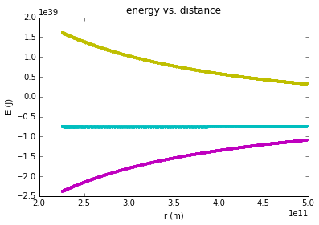

```python
#energy graphs
plt.title('energy vs. distance')
plt.ylabel('E (J)')
plt.xlabel('r (m)')
plt.plot(rlist,Ulist,'m.', rlist,Klist,'y.', rlist,Elist,'c.')
plt.show()
```

## One Star Model

### One Star Computational Model -- "Look Ma, Newton's second law is not used!"

In this model, we will replace the two stars with a single star that has a mass $\mu$ that is equal to the reduced mass of the system, where

$$\mu=\frac{m_1m_2}{m_1+m_2}$$

In this one-star model, its position is the relative position $\vec{r}$, where

$$\vec{r} = \vec{r}_1-\vec{r}_2$$$$r=|\vec{r}| = |\vec{r}_1-\vec{r}_2|$$

Its radial velocity is $\dot{r}$.

Its angular momentum is

$$\vec{L}=\vec{r}_1 \times m_1\vec{v}_1+\vec{r}_2 \times m_2\vec{v}_2$$

Its angular velocity $\dot{\phi}$ is

$$\dot{\phi}=\frac{|\vec{L}|}{r^2\mu}$$

Its potential energy is

$$U=-\frac{Gm_1m_2}{r}+\frac{|\vec{L}|^2}{2\mu r^2}$$

Its kinetic energy is

$$K=\frac{1}{2}\mu \dot{r}^2$$

Its total energy is $E=K+U$. Note that because it is a single star in orbit (around nothing except a point in space!), it speeds up and slows down. Thus its kinetic energy increases and decreases and its potential energy increases and decreases. However its total energy $E$ remains constant.

The advantage of using a single star model is that it is completely described by two differential equations, one of which is first order.

$$\mu\ddot{r}=-\frac{Gm_1m_2}{r^2}+\frac{L^2}{\mu r^3}$$

and

$$\mu \dot{\phi}=\frac{L}{r^2}$$

where $L=|\vec{L}|$ is the magnitude of the angular momentum of the star.

The velocity of the single star is calculated in polar coordinates.

$$\vec{v}=<\dot{r},r\dot{\phi}>$$

```python
scene2=canvas(title="One Star Model")

#reset variables
r1=vector(au,0,0)
r2=-m1/m2*r1
v1=vector(0,speed,0)
v2=-m1/m2*v1

#one star model
mu=m1*m2/(m1+m2)
L=m1*cross(r1,v1)+m2*cross(r2,v2)
Lmag=mag(L)
r=r1-r2
rmag=mag(r)
rdot=0
phi=0
phidot=Lmag/rmag/rmag/mu
v=vector(rdot,rmag*phidot)

#time
t=0

#data lists
Ulist=[]
Klist=[]
Elist=[]
rlist=[]

#ivisual objects
starmu=sphere(radius=20*R, pos=r, color=color.orange, make_trail=True, retain=400)

while t<4000*dt:
    rate(100)

    #update rmag
    rdotdot=(-G*m1*m2/(rmag*rmag)+Lmag*Lmag/(mu*rmag*rmag*rmag))/mu
    rdot=rdot+rdotdot*dt
    rmag=rmag+rdot*dt

    #update phi
    phidot=Lmag/rmag/rmag/mu
    phi=phi+phidot*dt

    #calculate velocity and position
    v=vector(rdot,rmag*phidot)
    r=vector(rmag*cos(phi),rmag*sin(phi),0)

    U=-G*m1*m2/rmag + Lmag*Lmag/(2*mu*rmag*rmag)
    K=1/2*mu*rdot*rdot
    E=U+K

    Ulist.append(U)
    Klist.append(K)
    Elist.append(E)
    rlist.append(rmag)

    #ivisual objects
    starmu.pos=r

    t=t+dt
```

[output not shown]

[output not shown]

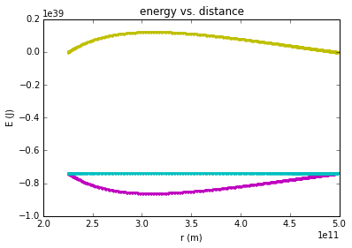

```python
#energy graphs
plt.title('energy vs. distance')
plt.xlabel('r (m)')
plt.ylabel('E (J)')
plt.plot(rlist,Ulist,'m.', rlist,Klist,'y.', rlist,Elist,'c.')
plt.show()
```

# Example -- Numerically solving differential equations

A simple pendulum of length $b$ and mass $m$ is suspended in a gravitational field $g$ from a point on the circumference of a thin low-mass disc of radius $R$ that rotates counterclockwise with a constant angular velocity $\omega$ about is central axis as shown below.

[figure not shown]

The equation of motion for the angle $\theta$ of the pendulum with respect to the vertical is

$$\ddot{\theta}=-\omega^2\frac{R}{b}\cos{(\theta + \omega t)}-\frac{g}{b}\sin\theta$$

Using the Euler-Cromer method:

1. calculate $\ddot{\theta}$
2. update $\dot{\theta}$
3. update $\theta$

In Python, this looks like:

```
thetadotdot=-omega**2*R/b*cos(theta+omega*t)-g/b*sin(theta)
    thetadot=thetadot+thetadotdot*dt
    theta=theta+thetadot*dt
```

```python
scene=canvas("Pendulum hanging from rotating pivot")

omega=2*pi/2
g=9.8
b=1
R=b/5

phi=0
theta=30*pi/180
thetadot=0

t=0
dt=0.005

rpivot=R*vector(cos(phi),sin(phi),0)
bvec=b*vector(sin(theta),-cos(theta),0)
r=bvec+rpivot

wheel=cylinder(pos=vector(0,0,-R/10), axis=vector(0,0,R/10), radius=R, color=color.red)
pivot=sphere(pos=rpivot, radius=R/20, color=color.yellow)
pendulum=sphere(pos=r, radius=R/4, color=color.yellow, make_trail=True, retain=2000)
string=cylinder(pos=pivot.pos, axis=bvec, radius=R/20, color=color.yellow)

while t<50:
    rate(100)

    thetadotdot=-omega**2*R/b*cos(theta+omega*t)-g/b*sin(theta)
    thetadot=thetadot+thetadotdot*dt
    theta=theta+thetadot*dt

    phi=phi+omega*dt

    rpivot=R*vector(cos(phi),sin(phi),0)
    bvec=b*vector(sin(theta),-cos(theta),0)
    r=bvec+rpivot

    pivot.pos=rpivot
    pendulum.pos=r
    string.pos=rpivot
    string.axis=r-rpivot

    t=t+dt
```

[output not shown]

# Example -- Plot Experimental Data

```python
from IPython.display import HTML
from base64 import b64encode
video = open("video_disk_accelerated_rocket.mov", "rb").read()
video_encoded = b64encode(video)
video_tag = '<video controls alt="test" src="data:video/x-m4v;base64,{0}">'.format(video_encoded)
HTML(data=video_tag)
```

[video not shown]

[output not shown]

```python
#t (s) and omega (deg/s)

data = """
0.033	7.9
0.067	22.8
0.1	45.8
0.133	76.1
0.167	109.7
0.2	147.7
0.234	193.2
0.267	232.3
0.3	254.2
0.334	274.7
0.367	297.4
0.4	318.1
0.434	335.2
0.467	349.1
0.501	371.4
0.534	400.3
0.567	421.5
0.601	437.5
0.634	460.4
0.667	472.7
0.701	491.8
0.734	518.9
0.767	533.3
0.801	550.5
0.834	561.8
0.868	570.0
0.901	578.5
0.934	589.7
0.968	593.6
1.001	589.8
1.034	606.7
1.068	624.6
1.101	638.9
1.134	666.8
1.168	698.0
1.201	735.5
1.235	767.4
1.268	784.3
1.301	800.4
1.335	815.7
1.368	828.9
1.401	827.2
1.435	813.1
1.468	811.8
1.502	806.2
1.535	816.9
1.568	845.8
1.602	883.6
1.635	938.0
1.668	981.7
1.702	1012.1
1.735	1024.3
1.768	1027.8
1.802	1006.6
1.835	978.3
1.869	959.8
1.902	957.7
1.935	992.7
1.969	1052.1
2.002	1121.2
2.035	1169.7
2.069	1183.1
2.102	1157.3
2.135	1112.8
2.169	1065.2
2.202	1027.6
2.236	1016.7
2.269	1039.4
2.302	1088.5
2.336	1145.0
2.369	1181.2
2.402	1180.0
2.436	1154.2
2.469	1104.6
2.503	1048.4
2.536	1014.9
2.569	1017.1
2.603	1050.6
2.636	1094.9
2.669	1144.3
2.703	1178.7
2.736	1173.7
2.769	1142.8
2.803	1087.3
2.836	1045.6
2.87	1012.4
2.903	1005.5
2.936	1047.9
2.97	1096.2
3.003	1150.2
3.036	1171.1
3.07	1155.3
3.103	1130.6
3.136	1080.1
3.17	1029.0
3.203	1003.7
3.237	1004.3
""".split('\n')  # split this string on the "newline" character.

print(len(data))
```

```
99
```

```
<function matplotlib.pyplot.show>
```

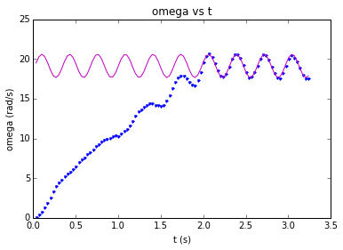

```python
#
# Here we'll take the list of strings defined above and break it into actual numbers in
# mks units.
#

tlist = []
omegalist = []
for s in data:
    if s:
        t,omega = s.split()     # break string in two
        t=float(t)          # convert time to float
        omega=float(omega)/180*pi #convert omega to float
        tlist.append(t)
        omegalist.append(omega)

#print "tlist=",tlist
#print "omegalist=",omegalist

from numpy import *
omegatheor=1.465*sin(19.21*array(tlist)+5.905)+19.12

fig1 = plt.figure()
plt.title('omega vs t')
plt.xlabel('t (s)')
plt.ylabel('omega (rad/s)')
plt.plot(tlist, omegalist,'b.',tlist,omegatheor,'m-')
plt.show
```

```python
import plotly.plotly as py
import plotly.tools as tls
from plotly.graph_objs import *
py.sign_in("hpuphysics", "fwxi6w237k")
py.iplot_mpl(fig1, strip_style = True)
```

[interactive chart not shown]

## Computer Model

[figure not shown]

$$ \frac{d\omega_{A,z}}{dt} = \ddot{\phi} = \frac{ F_{thrust}R -(m_1+m_2)gd\cos(\phi)}{(I_{disk}+I_1+I_2)} $$$$ d = \left(\frac{m_1-m_2}{m_1+m_2}\right) R \\ F_{thrust} =-\dot{m}v_{exhaust} $$

### After burnout

```
d =  0.223513043478
```

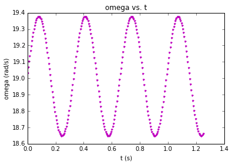

```python
#disk
M=2.94
R=0.6048/2
m1=0.52
m2=0.15*m1
d=(m1-m2)/(m1+m2)*R
I=R*R*(1/2*M+m1+m2)
print("d = ",d)

#initial angle with respect to -y axis
phi_deg=180
phi=phi_deg*pi/180 #phi in rad

#initial angular velocity
phidot=19  #rad/s

#gravitational field in N/kg
g=9.8

t=0
dt=0.005

#position vector
r=d*vector(sin(phi),-cos(phi),0)

#period
T=0
ti=0
atpeak=False

tlist=[]
omegalist=[]
philist=[]

while t<1.25:
    omegai=phidot

    #update phidotdot, phidot, phi
    phidotdot=-(m1+m2)*g*d/I*cos(phi)
    phidot=phidot+phidotdot*dt
    phi=phi+phidot*dt

    #update r
    r=R*vector(sin(phi),-cos(phi),0)

    #find period
    if(phidotdot>0 and (phidot-omegai)<0.001 and phidot>19 and atpeak==False):
        ti=t
#        print("t_i = ",t)
        atpeak=True
    if(phidotdot>0 and (phidot-omegai)<0.001 and phidot>19 and atpeak==True):
        T=t-ti
        ti=t
#        print("T = ",T)


    tlist.append(t)
    omegalist.append(phidot)
    philist.append(phi)

    t=t+dt

plt.title('omega vs. t')
plt.xlabel('t (s)')
plt.ylabel('omega (rad/s)')
plt.plot(tlist,omegalist,'m.')
plt.show()
```

### While the engine is firing

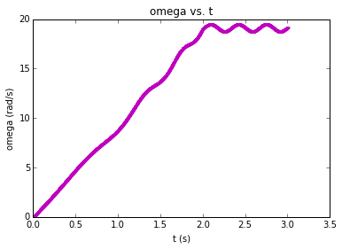

```python
from ivisual import *

g=9.8
mdisk=2.94 #kg
Rdisk=0.6048/2 #m
m0engine=520/1000 #kg
mfuel=0.85*m0engine #kg
vex=30 #m/s
mf=m0engine-mfuel
m=m0engine
m1=m0engine

r=0.3 #m
mdot=-mfuel/2 #2 s burn time

t=0
dt=0.001
theta=0
omega=0
Idisk=1/2*mdisk*Rdisk*Rdisk
Ieng1=m1*r*r
Ieng2=m*r*r
I=Idisk+Ieng1+Ieng2

r1=r*vector(cos(theta+pi),sin(theta+pi),0)
r2=r*vector(cos(theta),sin(theta),0)

tlist=[]
thetalist=[]
omegalist=[]
mlist=[]
taulist=[]

tau=vector(0,0,0)

while t<3:
    if(m>mf):
        m=m+mdot*dt
    Fgrav1=m1*vector(0,-g,0)
    Fgrav2=m*vector(0,-g,0)
    thrust=-mdot*vex

    taugrav1=cross(r1,Fgrav1)
    taugrav2=cross(r2,Fgrav2)
    if(m>mf):
        tauthrust=vector(0,0,thrust*r)
    else:
        tauthrust=vector(0,0,0)
    tau=taugrav1+taugrav2+tauthrust

    Ieng2=m*r*r
    I=Idisk+Ieng1+Ieng2

    omega=omega+tau.z/I*dt
    theta=theta+omega*dt

    r1=r*vector(cos(theta+pi),sin(theta+pi),0)
    r2=r*vector(cos(theta),sin(theta),0)

    t=t+dt

    tlist.append(t)
    thetalist.append(theta)
    omegalist.append(omega)
    mlist.append(m)
    taulist.append(tau.z)

plt.title('omega vs. t')
plt.xlabel('t (s)')
plt.ylabel('omega (rad/s)')
plt.plot(tlist,omegalist,'m.')
plt.show()
```

# Example -- Solving SE in Modern Physics

```
<function matplotlib.pyplot.show>
```

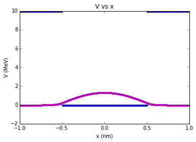

```python
#finite well

#x is in nm and E is in eV
E_rest=0.511e6
hc=1240
E=0.29766 #ground state for L=1
#E=1.1865 #first state for L=1
#E=2.6525 #second excited state for L=1

#values of x
N=1000

#left edge
x_left=-1

#right edge
x_right=1

#dx
dx=(x_right-x_left)/N

#Define and graph V
V=[]
Vmax=10

for x in arange(x_left,x_right,dx):
    leftWall=-0.5
    rightWall=0.5
    if(x<leftWall):
        V.append(Vmax)
    elif(x>rightWall):
        V.append(Vmax)
    else:
        V.append(0)

#Define and calculate Psi
Psi_0=0
Psi_1=1e-5

Psi=[]
i=0
for x in arange(x_left,x_right,dx):
    if(i==0):
        Psi.append(Psi_0)
    elif(i==1):
        Psi.append(Psi_1)
    else:
        f=2*Psi[i-1]-Psi[i-2]-8*pi*pi*E_rest/(hc*hc)*dx*dx*(E-V[i-1])*Psi[i-1]
        Psi.append(f)
    i=i+1

#find the integral of Psi^2 dx
integral=0
for j in arange(0,len(Psi),1):
    integral=integral+Psi[j]*Psi[j]*dx

#calculate the constant A^2 that normalizes the integral of Psi^2 dx
Asquared=1/integral
A=sqrt(Asquared)

#calculate the normalized Psi
PsiNormalized=[]
for j in arange(0,len(Psi),1):
    PsiNormalized.append(A*Psi[j])

fig1 = plt.figure()
plt.title('V vs x')
plt.xlabel('x (nm)')
plt.ylabel('V (MeV)')
plt.plot(arange(x_left,x_right,dx), V,'b.', arange(x_left,x_right,dx), PsiNormalized,'m.')
plt.show
```

# Example -- Computing Electric and Magnetic Fields

Compare the analytic calculation and numeric calculation of the electric field at a location along the axis of a ring of charge Q. (Demo program by Ruth Chabay.)

```python
IFrame('http://www.glowscript.org/#/user/matterandinteractions/folder/matterandinteractions/program/15-E-ring-demo-dE', width=700, height=700)
```

[interactive chart not shown]